# UHC Plots

### iSSF Example

The following is a demonstration of the workflow for an iSSF.

#### Prepare data

First, we combine steps (1) and (2) by splitting into train/test data and then generating available locations and attributing with covariates and model weights.

```r
# Load data
data(uhc_issf_locs)

# Format as steps
steps <- uhc_issf_locs |>
  make_track(x, y, t, crs = 32612) |>
  steps()

# Split into train (80%) and test (20%)
set.seed(1)
steps$train <- rbinom(n = nrow(steps),
                      size = 1, prob = 0.8)
train <- steps[steps$train == 1, ]
test <- steps[steps$train == 0, ]

# Generate available steps, attribute
train_dat <- train |>
  random_steps(n_control = 15) |>
  # Attach covariates
  extract_covariates(hab) |>
  # Additional movement parameters
  mutate(log_sl_ = log(sl_),
         cos_ta_ = cos(ta_)) |>
  # Drop 'train' column
  dplyr::select(-train) |>
  # Get rid of any NAs (sometimes available steps fall outside of raster)
  na.omit()

test_dat <- test |>
  random_steps(n_control = 15) |>
  # Attach covariates
  extract_covariates(hab) |>
  # Additional movement parameters
  mutate(log_sl_ = log(sl_),
         cos_ta_ = cos(ta_)) |>
  # Drop 'train' column
  dplyr::select(-train) |>
  # Get rid of any NAs (sometimes available steps fall outside of raster)
  na.omit()
```

#### Fit model(s)

Now we move onto step (3), where we fit candidate models. We’ll start with a model that has an incorrect formulation.

```r
issf_wrong <- fit_issf(train_dat,
                       case_ ~
                         # Habitat
                         forage +
                         # Movement
                         sl_ + log_sl_ + cos_ta_ +
                         # Strata
                         strata(step_id_), model = TRUE)
```

We will also fit the correct model, using the structure used to generate the data.

```r
issf_right <- fit_issf(train_dat,
                       case_ ~
                         # Habitat
                         forage + temp + I(temp^2) + pred + cover + dist_to_cent +
                         # Movement
                         sl_ + log_sl_ + cos_ta_ +
                         # Strata
                         strata(step_id_), model = TRUE)
```

#### Prepare UHC plot data

Next, onto step (4), where we use `prep_uhc()` to prepare the UHC data. This is the function that does most of the heavy lifting (*i.e.*, the bootstrapping).

```r
# Prep under wrong model
uhc_issf_wrong <- prep_uhc(object = issf_wrong, test_dat = test_dat,
                           n_samp = 20, verbose = FALSE)

# Prep under right model
uhc_issf_right <- prep_uhc(object = issf_right, test_dat = test_dat,
                           n_samp = 20, verbose = FALSE)
```

#### Plot UHC plots

Finally, we are ready to plot (step 5). First, the wrong model.

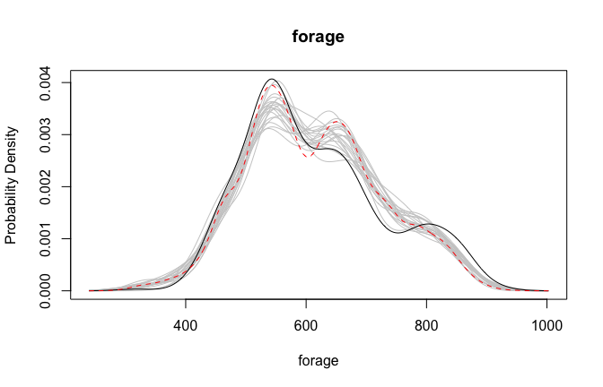

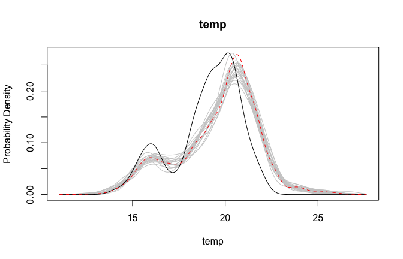

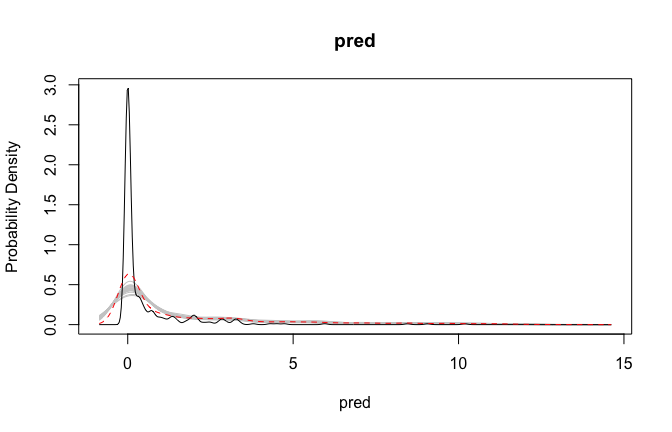

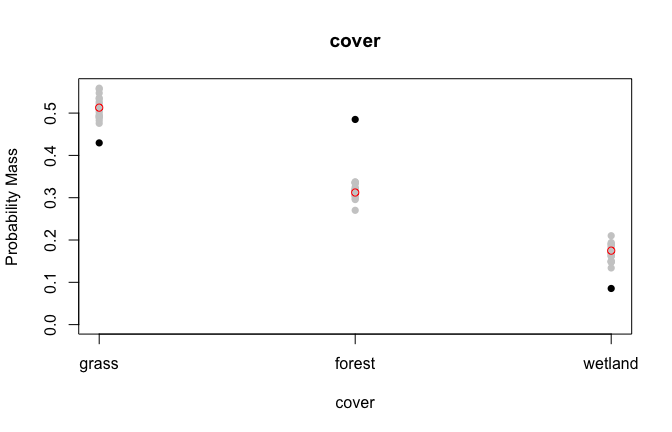

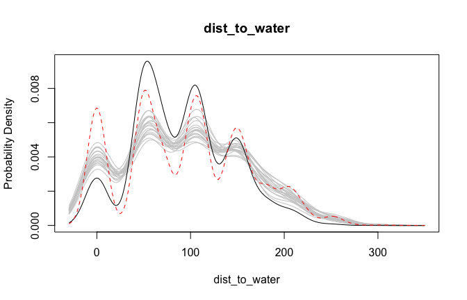

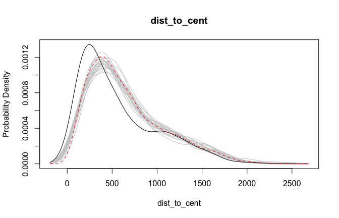

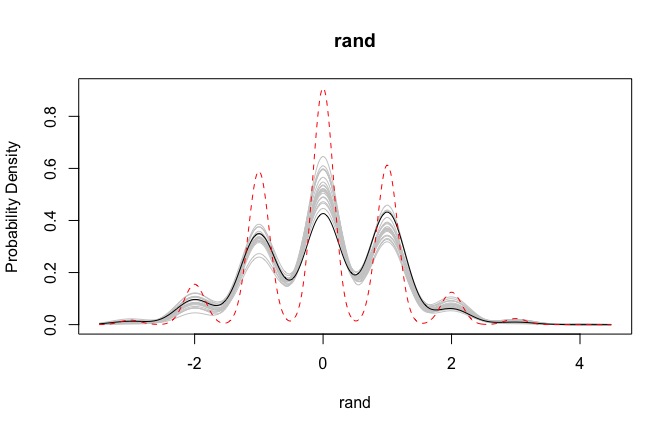

```r
plot(uhc_issf_wrong)
```

Now, the right model.

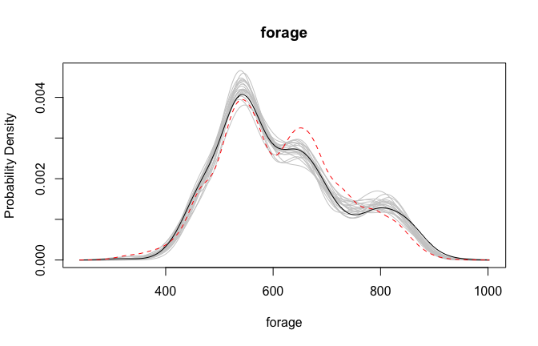

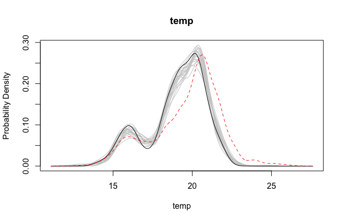

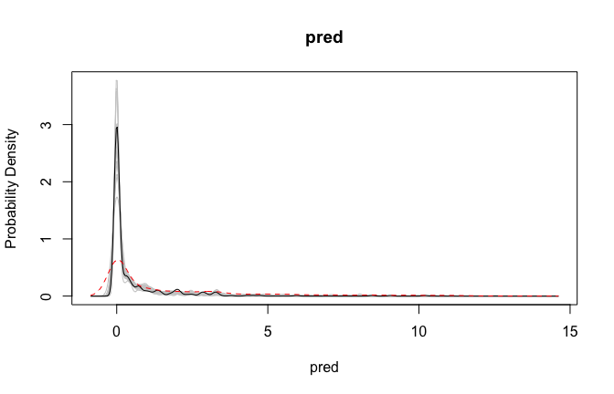

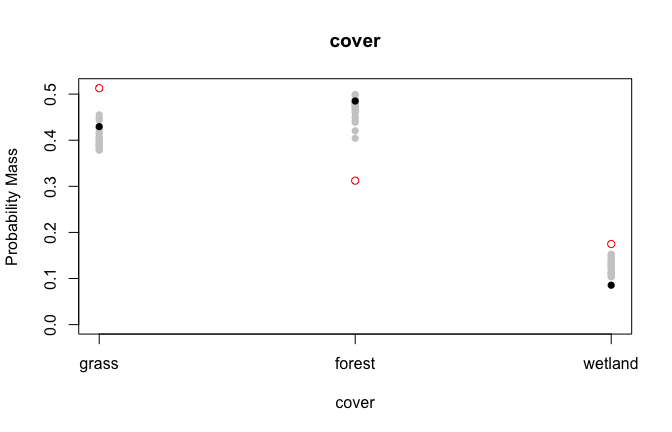

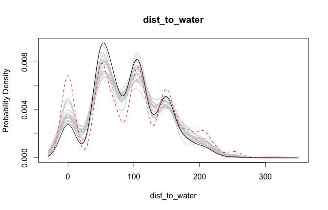

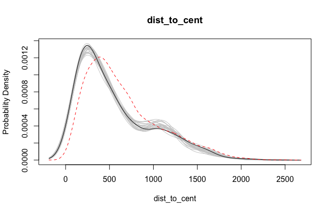

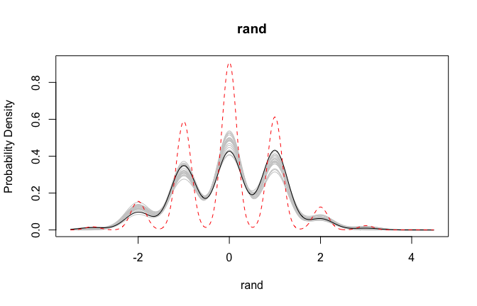

```r
plot(uhc_issf_right)
```

## Additional Methods

There is also a function to coerce a `uhc_data` object to `data.frame`. This would be useful, for example, if you wish to create a custom plot with `ggplot2` or another package.

```r
# Structure of `uhc_data` object
str(uhc_issf_right, 1)
```

```
#> List of 6
#>  $ orig:List of 7
#>  $ samp:List of 7
#>  $ vars: chr [1:7] "forage" "temp" "pred" "cover" ...
#>  $ lims:List of 7
#>  $ type: Named chr [1:7] "numeric" "numeric" "numeric" "factor" ...
#>   ..- attr(*, "names")= chr [1:7] "forage" "temp" "pred" "cover" ...
#>  $ resp: chr "case_"
#>  - attr(*, "class")= chr [1:2] "uhc_data" "list"
```

```r
# Coerce to data.frame
head(as.data.frame(uhc_issf_right), 10)
```

```
#>       var        x            y dist iter label
#> 1  forage 239.4147 1.108865e-06    U   NA  <NA>
#> 2  forage 240.9079 1.260712e-06    U   NA  <NA>
#> 3  forage 242.4012 1.427897e-06    U   NA  <NA>
#> 4  forage 243.8944 1.617745e-06    U   NA  <NA>
#> 5  forage 245.3876 1.828060e-06    U   NA  <NA>
#> 6  forage 246.8809 2.058069e-06    U   NA  <NA>
#> 7  forage 248.3741 2.308740e-06    U   NA  <NA>
#> 8  forage 249.8673 2.586933e-06    U   NA  <NA>
#> 9  forage 251.3606 2.893767e-06    U   NA  <NA>
#> 10 forage 252.8538 3.225675e-06    U   NA  <NA>
```

## References

Fieberg, J.R., Forester, J.D., Street, G.M., Johnson, D.H., ArchMiller, A.A., and Matthiopoulos, J. 2018. Used-habitat calibration plots: A new procedure for validating species distribution, resource selection, and step-selection models. *Ecography* 41:737–752.